# One4All_LA11

Braden Griebel, Andrew Duffy, Ahyo Falick, Luke Fanning

11/8/2019

# Braden Griebel Individual Section

## Selecting a Baby name

In 2017, the proportion of females included was 91.3% while the proportion of males was 93.44%, it was neccesary to make the assumption that these poportions are close to those for 2018 in order to calculate the proportions for 2018.

```r
tot_males<-bbnames18%>%filter(sex=="M")%>%summarize(total=sum(n))
tot_females<-bbnames18%>%filter(sex=="F")%>%summarize(total=sum(n))
tot_males<-tot_males[1,1]
tot_females<-tot_females[1,1]
prop<-babynames%>%filter(year==2017)%>%group_by(sex)%>%summarize(total=sum(prop))
prop_males<-prop[[2,2]]
prop_females<-prop[[1,2]]
tot_males<-tot_males/prop_males
tot_males<-tot_males[[1,1]]
tot_females<-tot_females/prop_females
tot_females<-tot_females[[1,1]]
bbnames18<-bbnames18%>%mutate("prop"=ifelse(sex=="M",n/tot_males,n/tot_females))
babynames<-full_join(babynames,bbnames18,by=c("name","prop","n","year","sex"))
bb<-babynames
```

First Step, eliminate names that are not obviously male or female. For this, names will be eliminated which have a proportion of males above .1% but below 99.9%. This will eliminate all names which are frequently used for both males and females.

```r
#create filter for names that are not obviously male or female, and then eliminate those names from the original dataset
filter1<-bb%>%group_by(name)%>%summarize("number_males"=sum(ifelse(sex=="M",n,0)),total=sum(n))
filter1<-filter1%>%mutate(prop_males=number_males/total)
filter1<-filter1%>%filter(prop_males>=.001&prop_males<=.999)
bb<-anti_join(bb,filter1,by="name")
```

Next, eliminate all names which can easily be shortened

```r
bb<-bb%>%mutate(length=str_length(name))
start<-bb%>%select(name,length)
start2<-start%>%mutate("start"=str_sub(name,1,2))%>%filter(length>2)
start3<-start%>%mutate("start"=str_sub(name,1,3))%>%filter(length>3)
start4<-start%>%mutate("start"=str_sub(name,1,4))%>%filter(length>4)
start5<-start%>%mutate("start"=str_sub(name,1,5))%>%filter(length>5)


#Keep any names whose first n letters are somewhere in babynames
start2<-semi_join(start2,babynames,by=c("start"="name"))
start3<-semi_join(start3,babynames,by=c("start"="name"))
start4<-semi_join(start4,babynames,by=c("start"="name"))
start5<-semi_join(start5,babynames,by=c("start"="name"))





bb<-anti_join(bb,start2,by="name")
bb<-anti_join(bb,start3,by="name")
bb<-anti_join(bb,start4,by="name")
bb<-anti_join(bb,start5,by="name")
```

Trendy but not trending: We will define thise as having a positive slope on their linear model for the last 10 years (greater than 0.000009 so that it is likely that it wasn’t just chance causing them to increase), so they are on the upswing, and eliminate the top 20 names to get rid of trendy names.

```r
#get the slopes of all the names in these last 5 years
filter2<-bb%>%filter(year>2018-10)
counter=1
filter3<-tibble(name=c(""),slope=c(1))
for(i in unique(filter2$name)){
  temp1<-filter2%>%filter(name==i)
  slope=coefficients(lm(prop~year,data=temp1))[[2]]
  filter3[counter,1]=i
  filter3[counter,2]=slope
  counter=counter+1
}
```

```r
#eliminte names with small or negative slopes
check<-filter3%>%filter(slope>0.000009)
bb_final<-semi_join(bb,check,by="name")
y18<-bb_final%>%filter(year==2018)
```

```r
y18<-y18%>%mutate(rank=rank(desc(prop)))%>%arrange(rank)%>%filter(rank<20)
bb_final<-bb_final%>%anti_join(y18,by="name")
bb_final
```

```
## # A tibble: 769 x 6
##     year sex   name         n      prop length
##    <dbl> <chr> <chr>    <dbl>     <dbl>  <int>
##  1  1880 F     Etta       323 0.00331        4
##  2  1880 M     Hezekiah    11 0.0000929      8
##  3  1880 M     Bruno        7 0.0000591      5
##  4  1881 F     Etta       316 0.00320        4
##  5  1881 M     Hezekiah    12 0.000111       8
##  6  1881 M     Bruno        6 0.0000554      5
##  7  1882 F     Etta       352 0.00304        4
##  8  1882 M     Hezekiah     7 0.0000574      8
##  9  1882 M     Bruno        5 0.0000410      5
## 10  1883 F     Etta       352 0.00293        4
## # ... with 759 more rows
```

```r
bb_final<-bb_final%>%mutate(coded=ifelse(sex=="M",1,0))%>%group_by(name)%>%summarize(gender=mean(coded))%>%
  mutate(gender=ifelse(gender>.5,"M","F"))
```

```r
bb_final%>%filter(gender=="M")
```

```
## # A tibble: 6 x 2
##   name     gender
##   <chr>    <chr>
## 1 Axl      M
## 2 Bruno    M
## 3 Colson   M
## 4 Gannon   M
## 5 Hezekiah M
## 6 Ridge    M
```

```r
bb_final%>%filter(gender=="F")
```

```
## # A tibble: 7 x 2
##   name      gender
##   <chr>     <chr>
## 1 Aadhya    F
## 2 Aavya     F
## 3 Aya       F
## 4 Etta      F
## 5 Heavenly  F
## 6 Khelani   F
## 7 Scarlette F
```

Any of the above names meet the clients criteria, however, if I had to pick a name it would be Gannon for a male, and Scarlette for a female.

## Individual plots of your name’s popularity over time

Regular Expression matching my name “Br[ae][yei]?d[aeyi]+n”

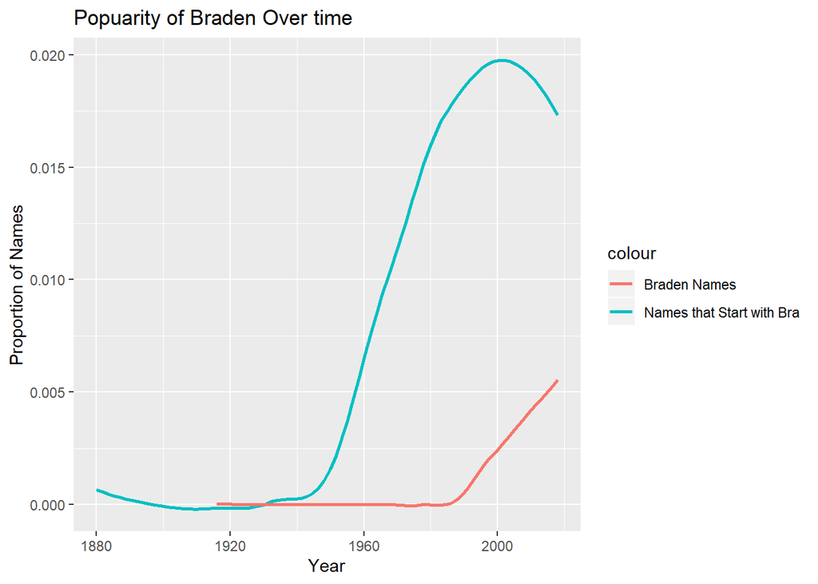

```r
first3<-babynames%>%filter(str_detect(name,"Bra"))%>%group_by(year)%>%summarize(prop=sum(prop))
braden_names<-babynames%>%filter(str_detect(name,"Br[ae][yei]?d[aeyi]+n"))%>%group_by(year)%>%summarize(prop=sum(prop))
ggplot(data=first3)+geom_smooth(aes(x=year,y=prop,color="Names that Start with Bra"),se=F)+
  geom_smooth(data=braden_names,aes(year,prop,color="Braden Names"),se=F)+labs(title="Popuarity of Braden Over time",
                                                                               x="Year",y="Proportion of Names")
```

**The regular expression matching my name is “Br[ae][yei]?d[aeyi]+n”. My name has increased in popularity since my birth. My name is less popular than all other names starting with Bra combined, but it is increaseing in popularity while Bra names are decreasing in popularity.**

## Ariel and Rachel regexs

The first Table Below shows the number of versions of Ariel or Rachel in all the years listed, the second shows the probability of a girl named after Ariel, Rachel and Both

```r
ariel_regex<-"^A[y]?r+[iaey]+[aeiy]+l+[e]?$"
rachael_regex<-"^R[yae]+ch[ae]+l+e?$"
ar<-babynames%>%filter(sex=="F")%>%filter(year%in%c(1973,1988,1990,2018))
a_orr<-ar%>%group_by(year)%>%summarize(Female=sum(n*(sex=="F")),
                                       Ariel=sum(n*str_detect(name,ariel_regex)),
                                       Rachel=sum(n*str_detect(name,rachael_regex)))
a_orrversions<-ar%>%group_by(year)%>%summarize(Ariel_Versions=sum(str_detect(name,ariel_regex)),
                                       Rachel_Versions=sum(str_detect(name,rachael_regex)))
a_orrversions
```

```
## # A tibble: 4 x 3
##    year Ariel_Versions Rachel_Versions
##   <dbl>          <int>           <int>
## 1  1973              2              13
## 2  1988             13              16
## 3  1990             16              16
## 4  2018              9               7
```

```r
a_orrprob<-a_orr%>%mutate(Probability_Ariel=Ariel/Female,
  Probability_Rachel=Rachel/Female,
  Probability_Ariel_Rachel=(Ariel+Rachel)/Female)%>%select(year,Probability_Ariel,Probability_Ariel_Rachel,Probability_Rachel)
a_orrprob
```

```
## # A tibble: 4 x 4
##    year Probability_Ariel Probability_Ariel_Rachel Probability_Rachel
##   <dbl>             <dbl>                    <dbl>              <dbl>
## 1  1973         0.0000357                  0.00577            0.00574
## 2  1988         0.000935                   0.0121             0.0112
## 3  1990         0.00288                    0.0136             0.0107
## 4  2018         0.00172                    0.00277            0.00105
```

## The Little Mermaid Effect

The first number below represents the percentile of the Change in proportion of the name “Ariel” out of female names starting with a vowel, the second is for the Ariel regex constructed earlier. Since the regex catches so many simmilar names, it is obviously going to be higher than most of the other names. But even just counting Ariel the percentile is still very high. Thus Ariel has clearly increased significantly in proportion following the release of the Little Mermaid

```r
vowel_f<-babynames%>%filter(sex=="F",str_detect(name,"^[AEIOU]"),year%in%c(1988,1990))
vowel_f<-vowel_f%>%spread(key=year,value=prop)%>%group_by(name)%>%summarize(`1988`=mean(`1988`,na.rm=T),`1990`=mean(`1990`,na.rm=T))
vowel_f<-na.omit(vowel_f)
vowel_f<-vowel_f%>%mutate(change=`1990`-`1988`)
vowel_f<-vowel_f%>%select(name,change)
ariel_names<-babynames%>%filter(str_detect(name,"^Ariel$"),year%in%c(1988,1990),sex=="F")%>%group_by(year)%>%summarize(prop=sum(prop))
ariel_name_change<-ariel_names[[2,2]]-ariel_names[[1,2]]
less_ariel<-vowel_f%>%filter(change<ariel_name_change)
ariel_percentile<-100*(nrow(less_ariel)/nrow(vowel_f))
ariel_percentile
```

```
## [1] 99.87013
```

```r
ariel_names<-babynames%>%filter(str_detect(name,ariel_regex),year%in%c(1988,1990),sex=="F")%>%group_by(year)%>%summarize(prop=sum(prop))
ariel_name_change<-ariel_names[[2,2]]-ariel_names[[1,2]]
less_ariel<-vowel_f%>%filter(change<ariel_name_change)
ariel_percentile<-100*(nrow(less_ariel)/nrow(vowel_f))
ariel_percentile
```

```
## [1] 100
```

Plots for Change in Female name Proportions between 1988 and 1990

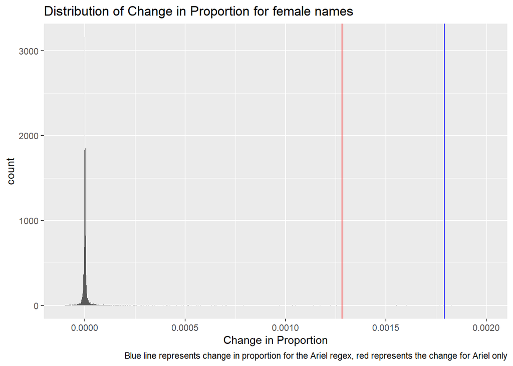

```r
female_names<-babynames%>%filter(sex=="F")
female_names<-female_names%>%spread(key=year,value=prop)%>%group_by(name)%>%summarize(`1988`=mean(`1988`,na.rm=T),`1990`=mean(`1990`,na.rm=T))
female_names<-na.omit(female_names)
female_names<-female_names%>%mutate(change=`1990`-`1988`)
female_names<-female_names%>%select(name,change)
female_ariel_name_change_regex<-female_names%>%filter(str_detect(name,ariel_regex))
archange_regex<-sum(female_ariel_name_change_regex$change)
female_ariel_name_change<-female_names%>%filter(str_detect(name,"^Ariel$"))
archange<-sum(female_ariel_name_change$change)



ggplot(female_names,aes(change))+geom_histogram(bins=1000)+geom_vline(xintercept=archange_regex,color="blue")+geom_vline(xintercept=archange,color="red")+xlim(-0.0001,0.002)+
  labs(title="Distribution of Change in Proportion for female names",x="Change in Proportion",caption="Blue line represents change in proportion for the Ariel regex, red represents the change for Ariel only")
```

**Observations:** As can be seen in the graph above, both the change for just Ariel and for all names caught by the Ariel regex, are far to the right of the rest of the changes in proportion for female names between 1988 and 1990. The change in proportion of Ariels is therefor very large in comparison to other female names over that time period. Most of the changes in proportion are right around zero, decreasing in frequency as the change moves away from zero.